# DATATHON

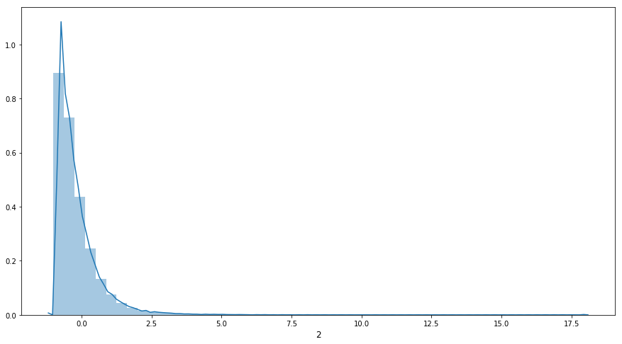

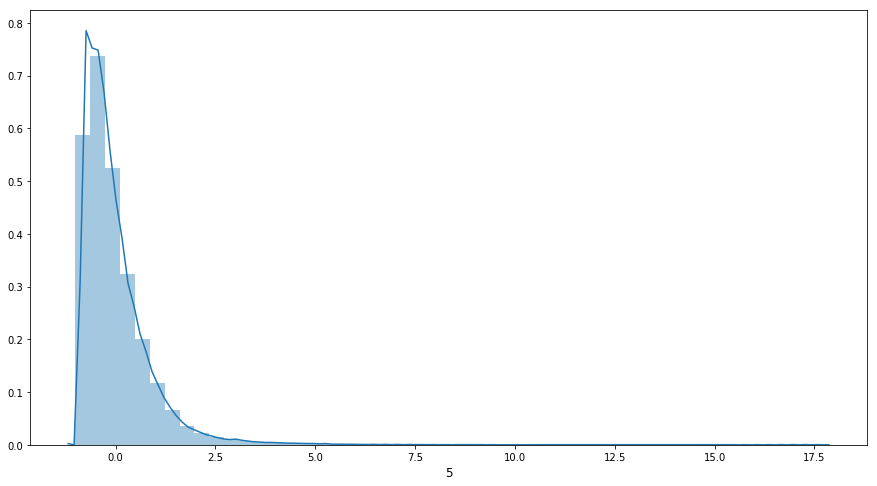

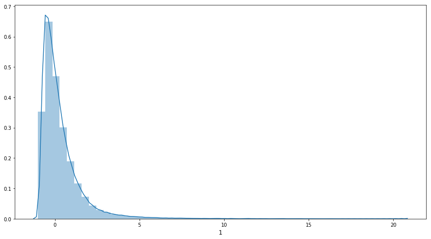

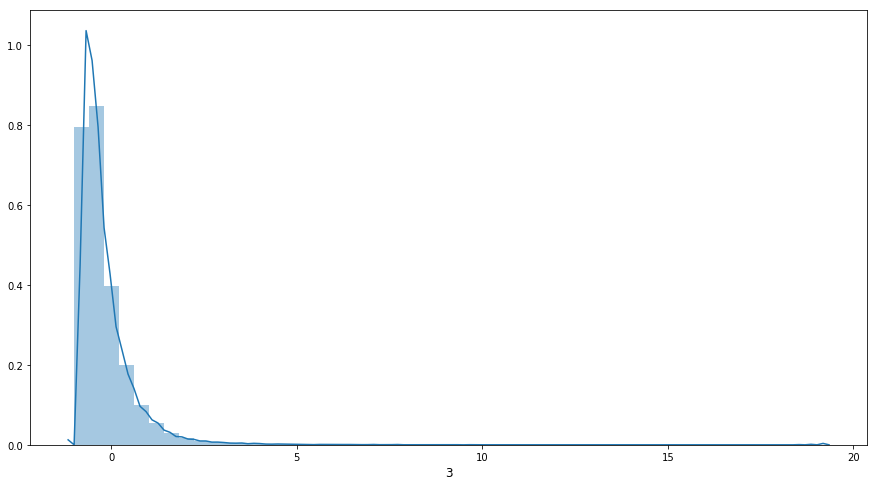

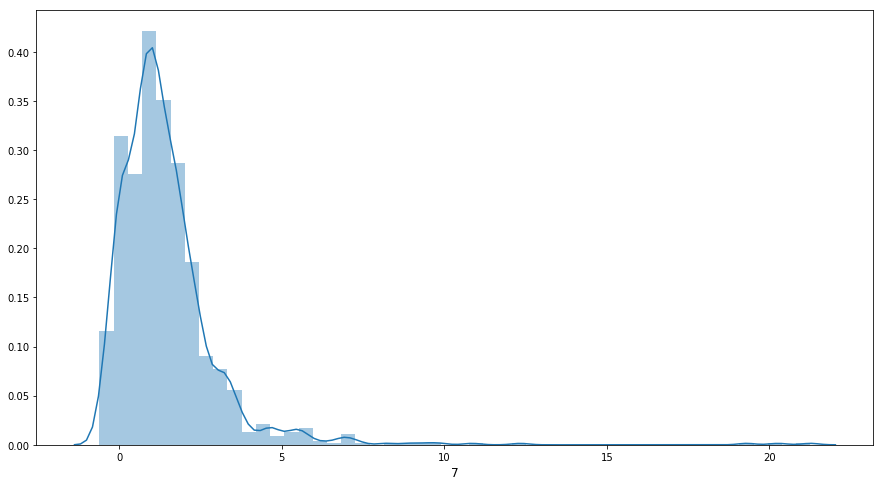

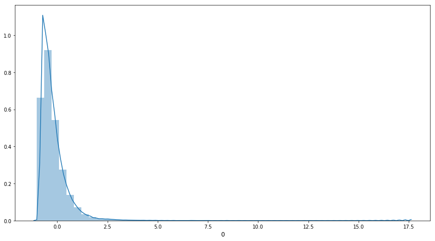

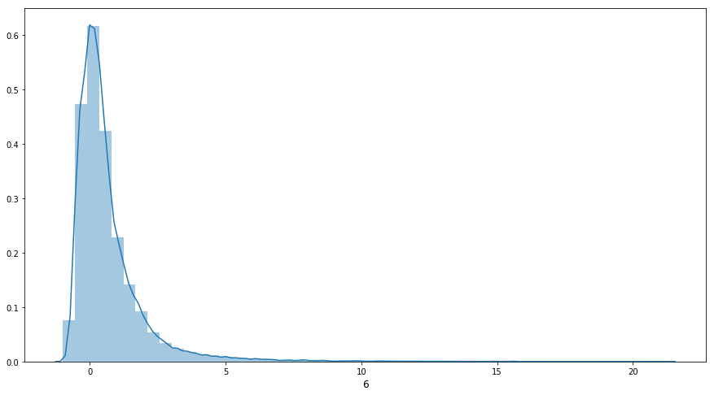

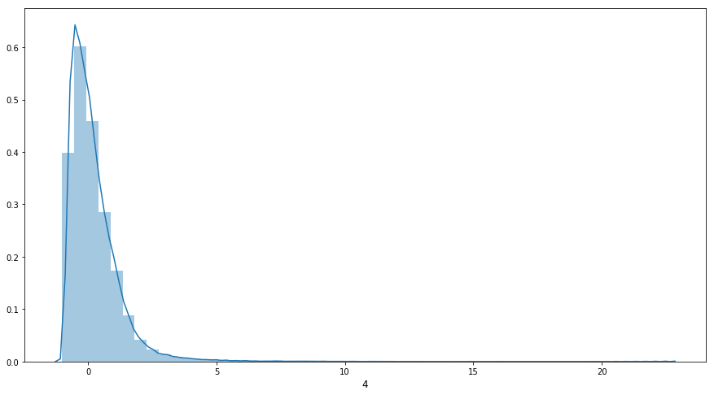

```python
for i, cls in enumerate(data_PCA.BookingCluster.unique()):
    plt.figure(i,figsize=(15,8))
    sns.distplot(data_PCA.loc[(data_PCA.BookingCluster == cls),'PricePerNight'])
    plt.xlabel(cls, fontsize=12)
```

We can see similar distributions of prices in each. A fair assumption would be that clusters are dense around the centroids representing similar bookings. Outlier prices would be on the tails of the distribution. By running a regression line on the clusters for the prices, we can identify the outliers in each clusters. These would represent price points which do not make much sense as per the cluster centroids.

##### (The logic is similar to that of Local Outlier Model, except that we are building statistical rules for an external variable - PricePerNight here)

##### Regression Modeling for each Cluster

```python
df_cluster = [None] * 8
```

```python
# Create new Data Frames for each of the 8 clusters
for i in range(0,8):
    df_cluster[i] = data_PCA.loc[data_PCA.BookingCluster == i,:]
```

We will now build regression models on each of the clusters. The outlier selection criteria will be based on

1. Regression scores - R2 and RMSE, Kurtosis (high and low defines clusters better ie. easier to interpret outliers)
2. Price points and assumption 2(<1% anomalies)

###### Cluster 0

```python
df_cluster[0].head()
```

| row_id | 0 | 1 | 2 | 3 | 4 | 5 | 6 | 7 | 8 | 9 | BookingCluster | PricePerNight |
| --- | --- | --- | --- | --- | --- | --- | --- | --- | --- | --- | --- | --- |
| 11 | 0.845113 | -0.887908 | 1.476775 | 0.025154 | 0.501200 | 0.785458 | 1.383884 | -0.094758 | -1.728300 | -0.409039 | 0 | -0.089006 |
| 19 | -0.505371 | 0.464827 | 1.044866 | 0.343541 | -0.584730 | 0.697559 | 1.745770 | -0.382318 | -1.372922 | -0.896806 | 0 | 1.510641 |
| 22 | -0.067568 | -0.248443 | 1.205699 | -0.433031 | -1.223224 | -0.897678 | 0.821342 | 0.367066 | -1.387628 | 0.195819 | 0 | -0.423795 |
| 33 | 0.024882 | 0.272926 | 1.311580 | 0.009227 | -0.772330 | 0.350717 | 1.516619 | -0.150465 | -1.418884 | 0.597554 | 0 | 0.275323 |
| 42 | -0.627393 | -0.591304 | 1.176218 | 0.044273 | -0.401618 | 0.716656 | 1.289843 | -0.060652 | -1.463443 | -0.117841 | 0 | 0.477629 |

```python
train = df_cluster[0].drop(['PricePerNight','BookingCluster'], axis = 1)
labels = df_cluster[0].PricePerNight
```

```python
regMod = linear_model.LinearRegression()
regMod.fit(train, labels)
pricePred = regMod.predict(train)
```

```python
metrics.r2_score(labels,pricePred)
```

```
0.4761441880930438
```

```python
metrics.mean_squared_error(labels,pricePred) ** (0.5)
```

```
0.5006814235539756
```

```python
residuals = labels - pricePred
residuals.describe()
```

```
count    1.250670e+05
mean     2.201192e-17
std      5.006834e-01
min     -2.801058e+00
25%     -2.405754e-01
50%     -5.528200e-02
75%      1.445207e-01
max      1.687391e+01
Name: PricePerNight, dtype: float64
```

```python
residuals.kurtosis()
```

```
97.09570815119247
```

```
Text(0,0.5,'Residuals')
```

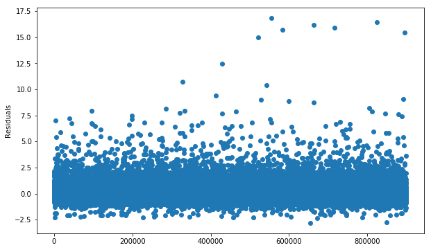

```python
plt.figure(figsize=(10,6))
plt.scatter(residuals.index,residuals)
plt.ylabel('Residuals')
```

```
Text(0.5,0,'Residuals')
```

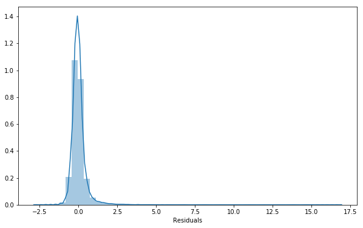

```python
plt.figure(figsize=(10,6))
sns.distplot(residuals)
plt.xlabel('Residuals')
```

```python
rightThreshold = 4.5
leftThreshold = -2.3
print(residuals[residuals>rightThreshold].size)
print(residuals[residuals<leftThreshold].size)
```

```
147
6
```

```python
cluster_0_anomalies = pd.DataFrame(residuals[(residuals>rightThreshold) | (residuals < leftThreshold)])
cluster_0_anomalies.columns=['Residuals']
```

```python
print(cluster_0_anomalies.shape)
cluster_0_anomalies.head()
```

```
(153, 1)
```

| row_id | Residuals |
| --- | --- |
| 1014 | -2.306445 |
| 3799 | 6.993490 |
| 5564 | 5.442417 |
| 16859 | 5.886450 |
| 17053 | 4.599126 |

###### Cluster 1

```python
df_cluster[1].head()
```

| row_id | 0 | 1 | 2 | 3 | 4 | 5 | 6 | 7 | 8 | 9 | BookingCluster | PricePerNight |
| --- | --- | --- | --- | --- | --- | --- | --- | --- | --- | --- | --- | --- |
| 3 | -0.122936 | 0.314188 | 0.709994 | -0.391187 | -0.749486 | 1.168437 | -2.242094 | 0.921336 | -0.631974 | -0.721845 | 1 | -0.311005 |
| 13 | -0.335998 | 1.973847 | 0.235764 | -1.675903 | 1.104996 | -0.765097 | -1.576673 | 0.476902 | -0.610731 | -0.837297 | 1 | 0.902829 |
| 16 | 0.324324 | 0.755075 | 0.860627 | -0.295792 | -0.676070 | -0.151770 | -2.464805 | 1.140085 | -1.083789 | 1.199712 | 1 | -0.595665 |
| 34 | -0.376277 | 1.243307 | 0.614289 | -1.375255 | -1.548659 | 1.137475 | -1.314272 | 0.264163 | -0.030518 | -1.397160 | 1 | -0.683391 |
| 39 | -0.773766 | 2.523090 | 0.438452 | -0.538924 | 1.020984 | 1.221880 | -0.864803 | 0.131487 | -0.010012 | 0.113937 | 1 | -0.255505 |

```python
train = df_cluster[1].drop(['PricePerNight','BookingCluster'], axis = 1)
labels = df_cluster[1].PricePerNight
```

```python
regMod = linear_model.LinearRegression()
regMod.fit(train, labels)
pricePred = regMod.predict(train)
```

```python
metrics.r2_score(labels,pricePred)
```

```
0.22208120872950188
```

```python
metrics.mean_squared_error(labels,pricePred) ** (0.5)
```

```
1.1313306189422188
```

```python
residuals = labels - pricePred
residuals.describe()
```

```
count    1.109280e+05
mean    -1.743436e-16
std      1.131336e+00
min     -4.467742e+00
25%     -5.832354e-01
50%     -2.091587e-01
75%      2.310624e-01
max      1.954578e+01
Name: PricePerNight, dtype: float64
```

```python
residuals.kurtosis()
```

```
31.363417315246313
```

```
Text(0,0.5,'Residuals')
```

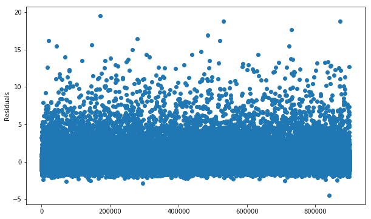

```python
plt.figure(figsize=(10,6))
plt.scatter(residuals.index,residuals)
plt.ylabel('Residuals')
```

```
Text(0.5,0,'Residuals')
```

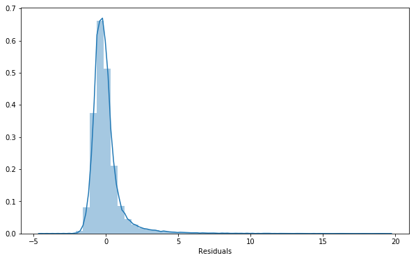

```python
plt.figure(figsize=(10,6))
sns.distplot(residuals)
plt.xlabel('Residuals')
```

```python
rightThreshold = 13
leftThreshold = -3
print(residuals[residuals>rightThreshold].size)
print(residuals[residuals<leftThreshold].size)
```

```
32
1
```

```python
cluster_1_anomalies = pd.DataFrame(residuals[(residuals>rightThreshold) | (residuals < leftThreshold)])
cluster_1_anomalies.columns=['Residuals']
```

```python
print(cluster_1_anomalies.shape)
cluster_1_anomalies.head()
```

```
(33, 1)
```

| row_id | Residuals |
| --- | --- |
| 20142 | 16.184777 |
| 44588 | 15.431079 |
| 68596 | 14.006748 |
| 118108 | 13.486185 |
| 145745 | 15.610377 |

###### Cluster 2

```python
df_cluster[2].head()
```

| row_id | 0 | 1 | 2 | 3 | 4 | 5 | 6 | 7 | 8 | 9 | BookingCluster | PricePerNight |
| --- | --- | --- | --- | --- | --- | --- | --- | --- | --- | --- | --- | --- |
| 0 | 0.479205 | 0.703927 | 1.412341 | 0.663251 | -0.283966 | -0.278070 | 0.263046 | -0.793438 | 1.953229 | 0.969553 | 2 | 1.063062 |
| 5 | -0.278532 | -0.582799 | 1.283382 | 1.373242 | -0.738598 | -0.494125 | -0.921536 | -0.252946 | 1.332607 | 0.692409 | 2 | -0.733520 |
| 7 | -0.518183 | -0.522858 | 1.130370 | 1.937956 | -0.916868 | -0.395975 | -0.979262 | -0.403520 | 0.875617 | 0.211761 | 2 | -0.450650 |
| 24 | -1.308476 | 0.175047 | 0.926524 | 0.632917 | 1.054020 | -0.317903 | -0.202223 | -0.612019 | 1.850692 | 0.790181 | 2 | -0.436327 |
| 27 | -0.112986 | -0.872803 | 1.097887 | 1.097461 | -0.761123 | -1.834775 | -1.231412 | 0.068221 | 0.780921 | -0.098743 | 2 | -0.211643 |

```python
train = df_cluster[2].drop(['PricePerNight','BookingCluster'], axis = 1)
labels = df_cluster[2].PricePerNight
```

```python
regMod = linear_model.LinearRegression()
regMod.fit(train, labels)
pricePred = regMod.predict(train)
```

```python
metrics.r2_score(labels,pricePred)
```

```
0.5647871325235112
```

```python
metrics.mean_squared_error(labels,pricePred) ** (0.5)
```

```
0.5353357969152523
```

```python
residuals = labels - pricePred
residuals.describe()
```

```
count    1.337830e+05
mean     6.706993e-16
std      5.353378e-01
min     -3.002523e+00
25%     -2.370501e-01
50%     -4.133338e-02
75%      1.187033e-01
max      1.602003e+01
Name: PricePerNight, dtype: float64
```

```python
residuals.kurtosis()
```

```
77.86308340425593
```

```
Text(0,0.5,'Residuals')
```

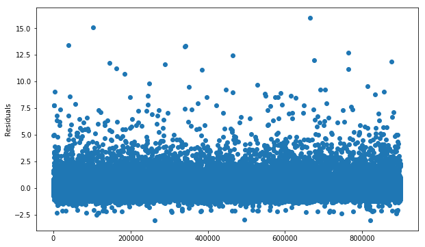

```python
plt.figure(figsize=(10,6))
plt.scatter(residuals.index,residuals)
plt.ylabel('Residuals')
```

```
Text(0.5,0,'Residuals')
```

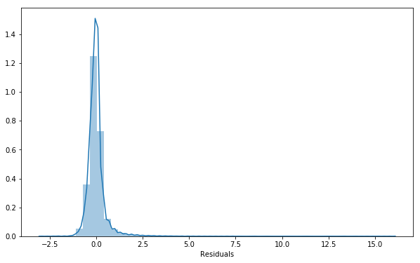

```python
plt.figure(figsize=(10,6))
sns.distplot(residuals)
plt.xlabel('Residuals')
```

```python
rightThreshold = 6
leftThreshold = -2.5
print(residuals[residuals>rightThreshold].size)
print(residuals[residuals<leftThreshold].size)
```

```
100
3
```

```python
cluster_2_anomalies = pd.DataFrame(residuals[(residuals>rightThreshold) | (residuals < leftThreshold)])
cluster_2_anomalies.columns=['Residuals']
```

```python
print(cluster_2_anomalies.shape)
cluster_2_anomalies.head()
```

```
(103, 1)
```

| row_id | Residuals |
| --- | --- |
| 1330 | 7.768947 |
| 2066 | 7.792100 |
| 3224 | 9.029191 |
| 8899 | 6.827791 |
| 8935 | 6.349852 |

###### Cluster 3

```python
df_cluster[3].head()
```

| row_id | 0 | 1 | 2 | 3 | 4 | 5 | 6 | 7 | 8 | 9 | BookingCluster | PricePerNight |
| --- | --- | --- | --- | --- | --- | --- | --- | --- | --- | --- | --- | --- |
| 4 | -0.780175 | -0.800730 | -1.064960 | -0.653402 | 1.341318 | -0.020423 | 0.128515 | 0.138521 | 0.245043 | 0.060215 | 3 | -0.475714 |
| 14 | -0.048566 | 1.361979 | -1.121405 | 1.827352 | 1.683455 | -0.240855 | -0.383651 | -0.262458 | -0.577785 | 0.620399 | 3 | 0.752442 |
| 23 | -1.082362 | -0.112576 | -1.164896 | -0.063248 | 0.781047 | -0.094802 | 0.163275 | -0.045882 | -0.005419 | 0.419192 | 3 | -0.379037 |
| 28 | -1.035651 | -0.235839 | -1.093252 | 0.876489 | 1.198519 | 0.581910 | -0.002238 | -0.163907 | -0.427578 | 1.065900 | 3 | -0.214328 |
| 29 | -1.062202 | -0.033277 | -1.108902 | 0.338747 | 0.771686 | -0.223165 | -0.224798 | 0.136138 | -0.213368 | 1.414535 | 3 | -0.625206 |

```python
train = df_cluster[3].drop(['PricePerNight','BookingCluster'], axis = 1)
labels = df_cluster[3].PricePerNight
```

```python
regMod = linear_model.LinearRegression()
regMod.fit(train, labels)
pricePred = regMod.predict(train)
```

```python
metrics.r2_score(labels,pricePred)
```

```
0.5654049955731417
```

```python
metrics.mean_squared_error(labels,pricePred) ** (0.5)
```

```
0.5107550737514301
```

```python
residuals = labels - pricePred
residuals.describe()
```

```
count    134420.000000
mean          0.000018
std           0.510757
min          -3.418849
25%          -0.193952
50%          -0.044817
75%           0.091181
max          17.361099
Name: PricePerNight, dtype: float64
```

```python
residuals.kurtosis()
```

```
90.8335928648356
```

```
Text(0,0.5,'Residuals')
```

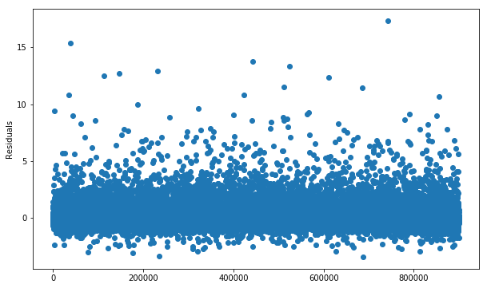

```python
plt.figure(figsize=(10,6))
plt.scatter(residuals.index,residuals)
plt.ylabel('Residuals')
```

```
Text(0.5,0,'Residuals')
```

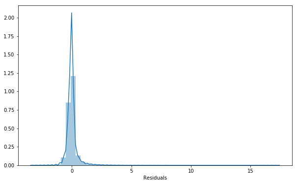

```python
plt.figure(figsize=(10,6))
sns.distplot(residuals)
plt.xlabel('Residuals')
```

```python
rightThreshold = 5.5
leftThreshold = -3
print(residuals[residuals>rightThreshold].size)
print(residuals[residuals<leftThreshold].size)
```

```
135
4
```

```python
cluster_3_anomalies = pd.DataFrame(residuals[(residuals>rightThreshold) | (residuals < leftThreshold)])
cluster_3_anomalies.columns=['Residuals']
```

```python
print(cluster_3_anomalies.shape)
cluster_3_anomalies.head()
```

```
(139, 1)
```

| row_id | Residuals |
| --- | --- |
| 2818 | 9.428341 |
| 20863 | 5.707793 |
| 25808 | 5.718289 |
| 34375 | 10.825993 |
| 38270 | 15.344841 |

###### Cluster 4

```python
df_cluster[4].head()
```

| row_id | 0 | 1 | 2 | 3 | 4 | 5 | 6 | 7 | 8 | 9 | BookingCluster | PricePerNight |
| --- | --- | --- | --- | --- | --- | --- | --- | --- | --- | --- | --- | --- |
| 17 | 1.573351 | 0.787613 | -0.487118 | -1.216253 | 0.248678 | 1.105750 | 2.068733 | -1.025083 | 0.996769 | -0.882029 | 4 | 1.353988 |
| 49 | 2.088437 | -0.295844 | -0.203846 | 0.131847 | 0.667869 | 1.147889 | 0.679040 | -0.378723 | 0.092054 | 0.880901 | 4 | 0.730959 |
| 55 | 2.156771 | -1.163527 | -0.254870 | -0.208209 | 0.205312 | -0.146276 | 0.117448 | 0.270916 | -0.203308 | 0.378608 | 4 | -0.303844 |
| 60 | 4.564086 | -0.618662 | 0.398435 | -1.727500 | 1.997634 | 0.868616 | 1.371218 | -0.602063 | 0.321549 | 1.969573 | 4 | 0.866127 |
| 72 | 2.119621 | -0.570877 | -0.242642 | -0.565565 | 1.469988 | 1.128459 | 0.436437 | -0.184335 | 0.191857 | 1.267963 | 4 | 0.665612 |

```python
train = df_cluster[4].drop(['PricePerNight','BookingCluster'], axis = 1)
labels = df_cluster[4].PricePerNight
```

```python
regMod = linear_model.LinearRegression()
regMod.fit(train, labels)
pricePred = regMod.predict(train)
```

```python
metrics.r2_score(labels,pricePred)
```

```
0.49396126552444874
```

```python
metrics.mean_squared_error(labels,pricePred) ** (0.5)
```

```
0.7174070789817586
```

```python
residuals = labels - pricePred
residuals.describe()
```

```
count    8.479500e+04
mean     1.788232e-16
std      7.174113e-01
min     -2.681537e+00
25%     -3.562650e-01
50%     -8.371770e-02
75%      2.179620e-01
max      1.871115e+01
Name: PricePerNight, dtype: float64
```

```python
residuals.kurtosis()
```

```
46.7257419759404
```

```
Text(0,0.5,'Residuals')
```

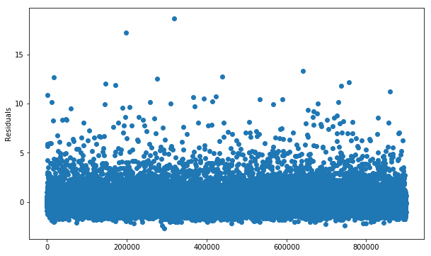

```python
plt.figure(figsize=(10,6))
plt.scatter(residuals.index,residuals)
plt.ylabel('Residuals')
```

```
Text(0.5,0,'Residuals')
```

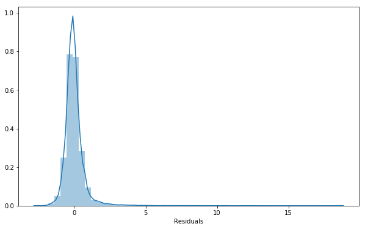

```python
plt.figure(figsize=(10,6))
sns.distplot(residuals)
plt.xlabel('Residuals')
```

```python
rightThreshold = 7
leftThreshold = -3
print(residuals[residuals>rightThreshold].size)
print(residuals[residuals<leftThreshold].size)
```

```
80
0
```

```python
cluster_4_anomalies = pd.DataFrame(residuals[(residuals>rightThreshold) | (residuals < leftThreshold)])
cluster_4_anomalies.columns=['Residuals']
```

```python
print(cluster_4_anomalies.shape)
cluster_4_anomalies.head()
```

```
(80, 1)
```

| row_id | Residuals |
| --- | --- |
| 1412 | 10.905826 |
| 12240 | 10.184312 |
| 14714 | 8.280034 |
| 18052 | 12.697547 |
| 38705 | 8.328798 |

###### Cluster 5

```python
df_cluster[5].head()
```

| row_id | 0 | 1 | 2 | 3 | 4 | 5 | 6 | 7 | 8 | 9 | BookingCluster | PricePerNight |
| --- | --- | --- | --- | --- | --- | --- | --- | --- | --- | --- | --- | --- |
| 1 | 0.275501 | -1.455008 | -0.844496 | -1.288080 | -0.840512 | -0.986995 | -0.425414 | 0.711756 | 0.307807 | -1.314518 | 5 | -0.417529 |
| 2 | 0.718216 | 1.501056 | -0.640290 | -0.284785 | -0.594555 | 1.398499 | 1.415269 | -1.124944 | 0.600015 | 0.788215 | 5 | 1.529439 |
| 6 | -0.828161 | -1.254729 | -0.768560 | 0.750229 | -1.572168 | 0.797026 | -0.470727 | 0.220952 | -0.101440 | 0.460283 | 5 | -0.963575 |
| 8 | 0.652379 | -0.554747 | -0.882758 | 0.144525 | -0.398437 | -0.297209 | -0.171059 | 0.063751 | -0.132103 | -1.368357 | 5 | -0.280570 |
| 10 | -0.661486 | -0.826697 | -0.782439 | -0.091113 | -1.631946 | 0.824691 | 0.069706 | 0.056407 | 0.525739 | -0.279575 | 5 | -0.638633 |

```python
train = df_cluster[5].drop(['PricePerNight','BookingCluster'], axis = 1)
labels = df_cluster[5].PricePerNight
```

```python
regMod = linear_model.LinearRegression()
regMod.fit(train, labels)
pricePred = regMod.predict(train)
```

```python
metrics.r2_score(labels,pricePred)
```

```
0.5807366757645991
```

```python
metrics.mean_squared_error(labels,pricePred) ** (0.5)
```

```
0.5752464651867379
```

```python
residuals = labels - pricePred
residuals.describe()
```

```
count    2.433210e+05
mean    -1.360750e-15
std      5.752476e-01
min     -4.981873e+00
25%     -2.297643e-01
50%     -5.857395e-02
75%      1.031718e-01
max      1.408754e+01
Name: PricePerNight, dtype: float64
```

```python
residuals.kurtosis()
```

```
56.01398760419862
```

```
Text(0,0.5,'Residuals')
```

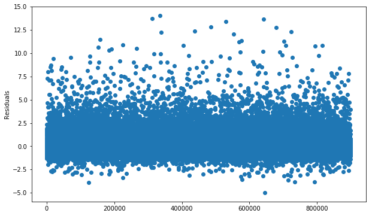

```python
plt.figure(figsize=(10,6))
plt.scatter(residuals.index,residuals)
plt.ylabel('Residuals')
```

```
Text(0.5,0,'Residuals')
```

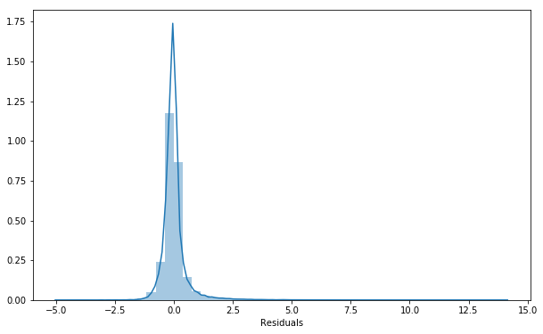

```python
plt.figure(figsize=(10,6))
sns.distplot(residuals)
plt.xlabel('Residuals')
```

```python
rightThreshold = 7
leftThreshold = -3.1
print(residuals[residuals>rightThreshold].size)
print(residuals[residuals<leftThreshold].size)
```

```
127
14
```

```python
cluster_5_anomalies = pd.DataFrame(residuals[(residuals>rightThreshold) | (residuals < leftThreshold)])
cluster_5_anomalies.columns=['Residuals']
```

```python
print(cluster_5_anomalies.shape)
cluster_5_anomalies.head()
```

```
(141, 1)
```

| row_id | Residuals |
| --- | --- |
| 1750 | 7.279603 |
| 3707 | 7.990967 |
| 7051 | 7.137882 |
| 11288 | 8.502345 |
| 11720 | 8.715117 |

###### Cluster 6

```python
df_cluster[6].head()
```

| row_id | 0 | 1 | 2 | 3 | 4 | 5 | 6 | 7 | 8 | 9 | BookingCluster | PricePerNight |
| --- | --- | --- | --- | --- | --- | --- | --- | --- | --- | --- | --- | --- |
| 12 | 0.409383 | 0.362265 | 0.882507 | 2.485446 | -0.363150 | -1.803797 | -1.296422 | -0.349282 | 0.369135 | -1.944214 | 6 | -0.018289 |
| 85 | 1.916206 | -0.789239 | -0.701978 | 1.327977 | 0.432679 | 0.052764 | -0.336865 | -0.177809 | -0.826437 | -2.520546 | 6 | -0.386198 |
| 88 | 2.142772 | -0.558636 | -0.511772 | 1.578425 | 0.306805 | 1.239809 | 0.159479 | -0.507188 | -0.587428 | -2.592633 | 6 | 0.243098 |
| 95 | 0.500093 | -0.023266 | -1.033270 | 1.753245 | -0.243918 | 0.548985 | -0.198091 | -0.393093 | -0.679294 | -2.708030 | 6 | 0.398855 |
| 122 | -0.200941 | 0.568603 | -1.452074 | 1.139176 | 1.432601 | -1.103973 | -0.311734 | -0.028963 | -0.506359 | -2.294841 | 6 | -0.339650 |

```python
train = df_cluster[6].drop(['PricePerNight','BookingCluster'], axis = 1)
labels = df_cluster[6].PricePerNight
```

```python
regMod = linear_model.LinearRegression()
regMod.fit(train, labels)
pricePred = regMod.predict(train)
```

```python
metrics.r2_score(labels,pricePred)
```

```
0.416112006800498
```

```python
metrics.mean_squared_error(labels,pricePred) ** (0.5)
```

```
1.0418707225610957
```

```python
residuals = labels - pricePred
residuals.describe()
```

```
count    5.700500e+04
mean     1.825884e-16
std      1.041880e+00
min     -3.810778e+00
25%     -4.868637e-01
50%     -1.619167e-01
75%      1.812263e-01
max      1.797791e+01
Name: PricePerNight, dtype: float64
```

```python
residuals.kurtosis()
```

```
32.39116338245531
```

```
Text(0,0.5,'Residuals')
```

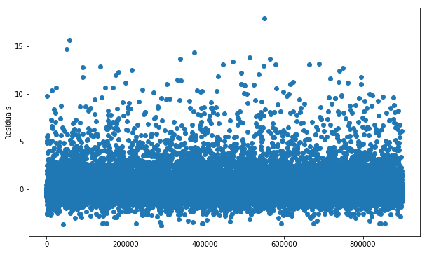

```python
plt.figure(figsize=(10,6))
plt.scatter(residuals.index,residuals)
plt.ylabel('Residuals')
```

```
Text(0.5,0,'Residuals')
```

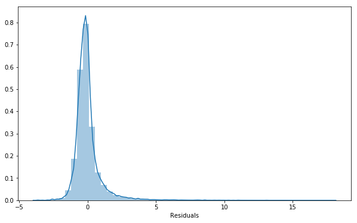

```python
plt.figure(figsize=(10,6))
sns.distplot(residuals)
plt.xlabel('Residuals')
```

```python
rightThreshold = 10
leftThreshold = -4
print(residuals[residuals>rightThreshold].size)
print(residuals[residuals<leftThreshold].size)
```

```
54
0
```

```python
cluster_6_anomalies = pd.DataFrame(residuals[(residuals>rightThreshold) | (residuals < leftThreshold)])
cluster_6_anomalies.columns=['Residuals']
```

```python
print(cluster_6_anomalies.shape)
cluster_6_anomalies.head()
```

```
(54, 1)
```

| row_id | Residuals |
| --- | --- |
| 13613 | 10.363078 |
| 24124 | 10.649609 |
| 50854 | 14.692485 |
| 58774 | 15.694273 |
| 91851 | 12.830930 |

###### Cluster 7

```python
df_cluster[7].head()
```

| row_id | 0 | 1 | 2 | 3 | 4 | 5 | 6 | 7 | 8 | 9 | BookingCluster | PricePerNight |
| --- | --- | --- | --- | --- | --- | --- | --- | --- | --- | --- | --- | --- |
| 9 | 1.465615 | 1.350828 | 1.106274 | 4.699473 | 1.413139 | 1.626622 | 7.581582 | 26.346496 | 6.865215 | 0.393287 | 7 | 0.599370 |
| 178 | 2.368353 | 3.441270 | 1.347817 | 4.843866 | 1.849840 | 1.809776 | 8.716957 | 25.713413 | 7.194368 | 2.362797 | 7 | 0.144630 |
| 530 | 2.057644 | 3.481610 | 1.344611 | 5.013137 | 1.613654 | 2.381044 | 8.832691 | 25.584898 | 7.394397 | 2.230648 | 7 | 0.314710 |
| 2588 | 1.579596 | 3.232572 | 0.360482 | 6.377193 | 0.976148 | -0.253423 | 7.336045 | 26.024943 | 5.586431 | -2.673311 | 7 | 1.074699 |
| 4691 | 2.831930 | 3.633379 | 0.452268 | 5.878034 | 1.645529 | -1.241754 | 7.789931 | 25.982012 | 5.641381 | -3.111540 | 7 | 1.179433 |

```python
train = df_cluster[7].drop(['PricePerNight','BookingCluster'], axis = 1)
labels = df_cluster[7].PricePerNight
```

```python
regMod = linear_model.LinearRegression()
regMod.fit(train, labels)
pricePred = regMod.predict(train)
```

```python
metrics.r2_score(labels,pricePred)
```

```
0.2125938394784207
```

```python
metrics.mean_squared_error(labels,pricePred) ** (0.5)
```

```
1.524191442865807
```

```python
residuals = labels - pricePred
residuals.describe()
```

```
count    1.068000e+03
mean    -2.785088e-13
std      1.524906e+00
min     -2.649388e+00
25%     -6.949101e-01
50%     -2.678954e-01
75%      2.353547e-01
max      1.745286e+01
Name: PricePerNight, dtype: float64
```

```python
residuals.kurtosis()
```

```
48.29786449779746
```

```
Text(0,0.5,'Residuals')
```

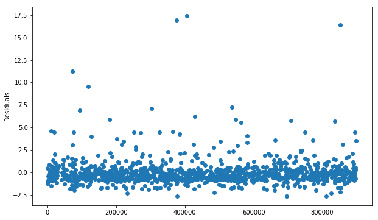

```python
plt.figure(figsize=(10,6))
plt.scatter(residuals.index,residuals)
plt.ylabel('Residuals')
```

```
Text(0.5,0,'Residuals')
```

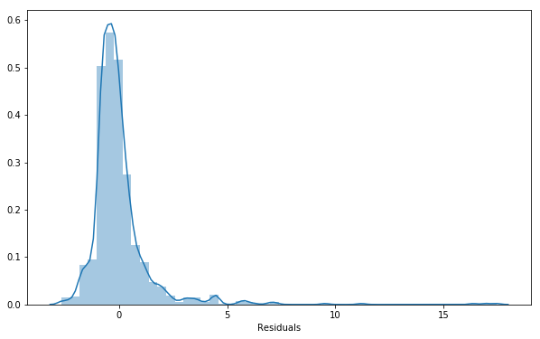

```python
plt.figure(figsize=(10,6))
sns.distplot(residuals)
plt.xlabel('Residuals')
```

```python
rightThreshold = 8
leftThreshold = -3
print(residuals[residuals>rightThreshold].size)
print(residuals[residuals<leftThreshold].size)
```

```
5
0
```

```python
cluster_7_anomalies = pd.DataFrame(residuals[(residuals>rightThreshold) | (residuals < leftThreshold)])
cluster_7_anomalies.columns=['Residuals']
```

```python
print(cluster_7_anomalies.shape)
cluster_7_anomalies.head()
```

```
(5, 1)
```

| row_id | Residuals |
| --- | --- |
| 71907 | 11.217906 |
| 118797 | 9.530392 |
| 375539 | 16.973416 |
| 405031 | 17.452864 |
| 851573 | 16.392423 |

```python
df_anomalyPred = cluster_0_anomalies.append([
                                             cluster_1_anomalies,
                                             cluster_2_anomalies,
                                             cluster_3_anomalies,
                                             cluster_4_anomalies,
                                             cluster_5_anomalies,
                                             cluster_6_anomalies,
                                             cluster_7_anomalies,
                                             ])
```

```python
df_anomalyPred.head()
```

| row_id | Residuals |
| --- | --- |
| 1014 | -2.306445 |
| 3799 | 6.993490 |
| 5564 | 5.442417 |
| 16859 | 5.886450 |
| 17053 | 4.599126 |

```python
df_anomalyPred.shape
```

```
(708, 1)
```

[figure not shown]

### Anomaly Labeling and Submission

```python
# Return a description of the anomalies
print(df_anomaly1.index)
print(df_anomaly1.index.shape)
print(df_anomaly1.index.unique().size)
```

```
Int64Index([  1013,   1046,   1965,   2273,   2292,   2490,   2516,   2583,
              2771,   3100,
            ...
            899414, 899415, 899417, 899433, 899438, 899452, 899461, 899469,
            899470, 899474],
           dtype='int64', length=8820)
(8820,)
8820
```

```python
print(df_anomaly2.index)
print(df_anomaly2.index.shape)
print(df_anomaly2.index.unique().size)
```

```
Int64Index([ 23073,  23537,  27815,  32092,  44680,  49265,  57407,  70675,
             73282,  87454,
            ...
            848874, 851662, 855805, 859394, 880888, 883813, 887007, 892812,
            894950, 897293],
           dtype='int64', length=112)
(112,)
112
```

```python
print(df_anomaly3.index)
print(df_anomaly3.index.shape)
print(df_anomaly3.index.unique().size)
```

```
Int64Index([   717,  14578,  22116,  23731,  31557,  33996,  49117,  65252,
             80070,  81760,
            ...
            842411, 842988, 852212, 869319, 870548, 878919, 883726, 884331,
            890846, 891518],
           dtype='int64', name='row_id', length=123)
(123,)
123
```

```python
print(df_anomalyPred.index)
print(df_anomalyPred.index.shape)
print(df_anomalyPred.index.unique().size)
```

```
Int64Index([  1014,   3799,   5564,  16859,  17053,  22774,  39214,  44580,
             47346,  51630,
            ...
            739917, 750302, 762137, 795630, 795988,  71907, 118797, 375539,
            405031, 851573],
           dtype='int64', name='row_id', length=708)
(708,)
708
```

```python
df_anomaly3.index.isin(df_anomalyPred.index).sum()
```

```
0
```

```python
# Aggregation of all the anomalies indexes
anomalyIndex = df_anomaly1.index.append([df_anomaly2.index,df_anomaly3.index,df_anomalyPred.index])
```

```python
anomalyIndex.unique().size
```

```
9763
```

```python
anomalyIndex.shape
```

```
(9763,)
```

```python
# Creating the variable 'anomaly' for final submission
finalPrediction =  pd.read_csv('DATATHON_STU_NEW.csv', index_col= 0)
finalPrediction = pd.DataFrame(finalPrediction.loc[:,'row_id'])
finalPrediction['anomaly'] = 0
```

```python
finalPrediction.shape
```

```
(899477, 2)
```

```python
finalPrediction.loc[finalPrediction.row_id.isin(anomalyIndex),'anomaly'] = 1
```

```python
print("TOTAL ANOMALIES IDENTIFIED:")
print(finalPrediction.anomaly.sum())

print("TOTAL ANOMALIES Percentage:")
print(round(((finalPrediction.anomaly.sum()/finalPrediction.shape[0])*100),2),"%")
```

```
TOTAL ANOMALIES IDENTIFIED:
9763
TOTAL ANOMALIES Percentage:
1.09 %
```

```python
# Saving the final submission dataset
finalPrediction.to_csv('TeamC_FinalPrediction.csv', sep=',', header=True)
```

---------------------------------------------------END OF DOCUMENT--------------------------------------------------